Pose-feedback presentation benchmark · first-pass screening

# Which composite lets a vision model read camera-pose error?

Eleven ways to show a reference photo against a mis-posed CAD render, scored by how well **Codex gpt-5.5** reads the applied camera error, discriminates two errors apart, and closes a correction loop. Deterministic grading — no LLM judge. T1 (below) is an N=1 screening pass over Codex; T3 and T2 are complete too, giving a full decision-rule preview — but the rule governs on Opus, whose run is paused (see "Reading the result").

subject · **Codex gpt-5.5**, high reasoning task · **T1** single-shot direction read **1782** cells · 11 arms × 6 pairs × 27 cases ≈**24.3M** tokens grading · **deterministic**

## The inputs

Every arm sees the same two images: the reference photograph (ground-truth pose) and a CAD render from a perturbed camera. The exemplars below use pair ch30-p002 with a **+15° azimuth** error applied to the render.

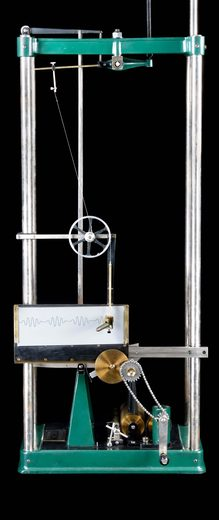

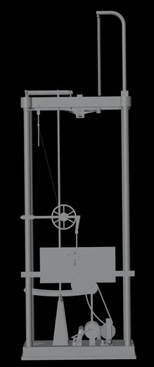

**Render · control**0° error baseline

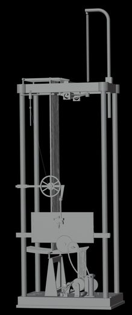

**Render · +15° az**the error to read

## Arm ranking

Headline metric is **macro sign accuracy** — did the model call the direction (−/0/+) of each of the six camera parameters right, macro-averaged over the three sign classes so the ~80%-0 labels can't inflate the score. Bar = macro sign %; also shown: magnitude-bucket accuracy, false-positive rate on the zero-error controls, and cost.

| # | arm | macro sign % | 95% CI | magnitude % | control FP % | median tok | lat s |
| --- | --- | --- | --- | --- | --- | --- | --- |
| 1 | P6 Checkerboard | 70.8 | 68–74 | 73 | 33 | 13536 | 31 |
| 2 | P5 Blend (subtle) | 67.0 | 58–75 | 67 | 67 | 13240 | 24 |
| 3 | P1 Blend (red overlay)incumbent | 65.7 | 62–70 | 64 | 83 | 13353 | 24 |
| 4 | P7 Green–magenta fusion | 65.7 | 61–71 | 69 | 100 | 13570 | 28 |
| 5 | P9 Edge overlay | 65.4 | 60–71 | 63 | 100 | 13457 | 25 |
| 6 | P11 Dashboard | 63.8 | 60–68 | 68 | 100 | 13215 | 22 |
| 7 | P4 Onion ladder | 62.7 | 56–69 | 66 | 100 | 14072 | 25 |
| 8 | P8 Difference heatmap | 62.1 | 59–66 | 64 | 67 | 14022 | 23 |
| 9 | P10 Flicker pairmulti-image | 60.0 | 56–65 | 65 | 100 | 13857 | 24 |
| 10 | P2 Side-by-sidemulti-image | 59.5 | 55–65 | 66 | 100 | 13842 | 21 |
| 11 | P3 Side-by-side + gridmulti-image | 58.7 | 51–67 | 62 | 100 | 14030 | 22 |

## What each presentation looks like

The same +15° case rendered through all eleven arms, ordered by rank. This is the comparison: read each composite as the model must, then check its score. The registration-preserving overlays (checkerboard, blends, fusion, edges) sit at the top; the two-image arms (side-by-side, flicker) sit at the bottom — consistent with the known VLM weakness at multi-image reasoning.

#1 · P671%

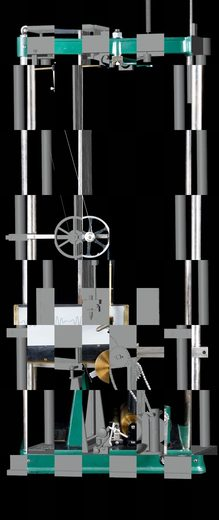

Checkerboard

macro sign 70.8% · magnitude 73%

control false-positives 33%

#2 · P567%

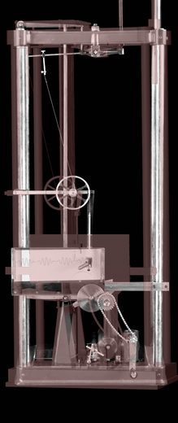

Blend (subtle)

macro sign 67.0% · magnitude 67%

control false-positives 67%

#3 · P166%

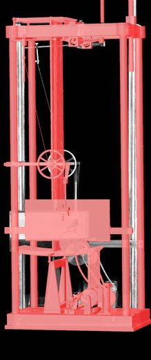

Blend (red overlay)

macro sign 65.7% · magnitude 64%

control false-positives 83%

#4 · P766%

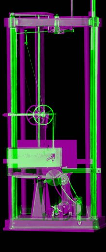

Green–magenta fusion

macro sign 65.7% · magnitude 69%

control false-positives 100%

#5 · P965%

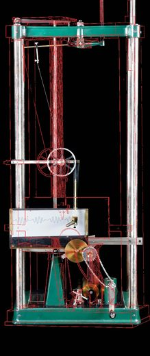

Edge overlay

macro sign 65.4% · magnitude 63%

control false-positives 100%

#6 · P1164%

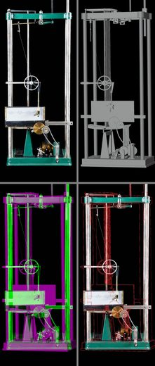

Dashboard

macro sign 63.8% · magnitude 68%

control false-positives 100%

#7 · P463%

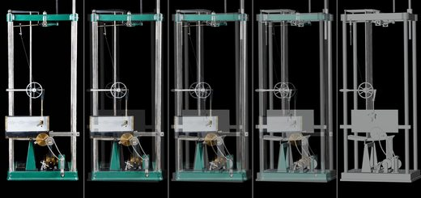

Onion ladder

macro sign 62.7% · magnitude 66%

control false-positives 100%

#8 · P862%

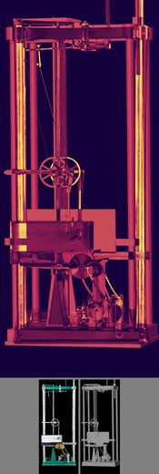

Difference heatmap

macro sign 62.1% · magnitude 64%

control false-positives 67%

#9 · P1060%

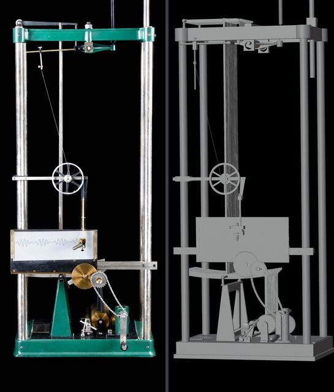

Flicker pair

macro sign 60.0% · magnitude 65%

control false-positives 100%

#10 · P260%

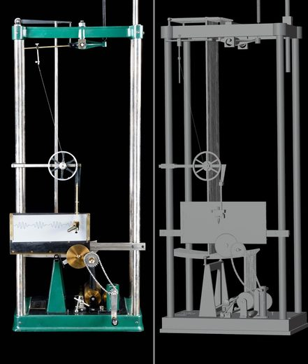

Side-by-side

macro sign 59.5% · magnitude 66%

control false-positives 100%

#11 · P359%

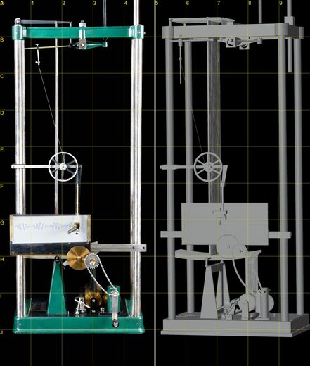

Side-by-side + grid

macro sign 58.7% · magnitude 62%

control false-positives 100%

## Per-parameter sign accuracy

≤55% 55–68% >68%

| arm | az | el | roll | target-x | target-y | zoom |
| --- | --- | --- | --- | --- | --- | --- |
| **P6** Checkerboard | 74 | 82 | 77 | 61 | 71 | 59 |
| **P5** Blend (subtle) | 73 | 73 | 76 | 62 | 61 | 57 |
| **P1** Blend (red overlay) | 72 | 69 | 71 | 64 | 56 | 62 |
| **P7** Green–magenta fusion | 68 | 71 | 69 | 65 | 61 | 60 |
| **P9** Edge overlay | 65 | 75 | 66 | 62 | 62 | 62 |
| **P11** Dashboard | 68 | 63 | 74 | 62 | 49 | 67 |
| **P4** Onion ladder | 70 | 64 | 67 | 62 | 55 | 59 |
| **P8** Difference heatmap | 73 | 73 | 75 | 56 | 50 | 46 |
| **P10** Flicker pair | 67 | 58 | 76 | 46 | 51 | 62 |
| **P2** Side-by-side | 59 | 55 | 74 | 48 | 52 | 69 |
| **P3** Side-by-side + grid | 61 | 58 | 73 | 43 | 54 | 62 |

## T3 — can it tell two errors apart?

A different question: shown two stimuli of the same pair with different error magnitudes, pick the better-aligned one (2AFC, chance = 50%). This is **discrimination**, not absolute reading — and the ranking nearly **inverts** T1. The two-image arms (side-by-side, flicker) that were worst at reading a single stimulus are best at telling two apart; the overlay arms that won T1 sit near chance here. The winner depends on the task.

| arm | discrimination % | vs chance | strongest axis |
| --- | --- | --- | --- |
| P3 Side-by-side + grid | 66.7 | +16.7 | tx 94% |
| P10 Flicker pair | 65.3 | +15.3 | roll 78% |
| P2 Side-by-side | 62.5 | +12.5 | roll 72% |
| P5 Blend (subtle) | 60.4 | +10.4 | tx 78% |
| P7 Green–magenta fusion | 59.7 | +9.7 | tx 83% |
| P4 Onion ladder | 59.0 | +9.0 | roll 72% |
| P8 Difference heatmap | 59.0 | +9.0 | tx 83% |
| P6 Checkerboard | 56.2 | +6.2 | roll 78% |
| P11 Dashboard | 56.2 | +6.2 | tx 89% |
| P9 Edge overlay | 54.9 | +4.9 | tx 78% |
| P1 Blend (red overlay) | 52.8 | +2.8 | el 56% |

## T2 — closing the loop complete · 144/144

The production question: iterate — read stimulus, propose a camera correction, re-render, repeat (≤6 rounds). Convergence = az/el/roll ≤ 1°, target ≤ 5 mm, zoom ± 3%. Run on the top-3 T1 arms plus the incumbent P1, 6 pairs × 6 pinned starts (one per parameter class). Non-converged cells enter the median as round 7 (censored at max+1).

| arm | n | converged | median rounds |
| --- | --- | --- | --- |
| P5 Blend (subtle) | 36 | 24/36 (67%) | 2 |
| P6 Checkerboard | 36 | 23/36 (64%) | 2 |
| P7 Green–magenta fusion | 36 | 21/36 (58%) | 4 |
| P1 Blend (red overlay) | 36 | 18/36 (50%) | 7 |

## Decision rule — applied to Codex (generalization check)

The benchmark's rule: adopt the arm that wins T1 macro sign accuracy over the incumbent (P1) by **≥5 points** *and* is non-inferior on T2 — convergence rate within 5 points of the best arm, median rounds-to-converge at most 1 round more. **The rule governs on the Opus numbers** (Opus runs pose feedback in production); this section applies it to Codex as the generalization check, since the Opus run is currently paused (quota). Treat this as a preview, not the adoption decision.

| arm | T1 macro sign % | margin vs P1 | T2 converged % | vs best conv | median rounds | vs best rounds | passes? |
| --- | --- | --- | --- | --- | --- | --- | --- |
| P5 Blend (subtle) | 67.0 | +1.3 | 67 | best | 2 | best | no |
| P6 Checkerboard | 70.8 | +5.1 | 64 | -3 | 2 | +0 | YES |
| P7 Green–magenta fusion | 65.7 | -0.0 | 58 | -8 | 4 | +2 | no |
| P1 Blend (red overlay) | 65.7 | +0.0 | 50 | -17 | 7 | +5 | no |

**On Codex, P6 (Checkerboard) clears both bars.** It beats the incumbent P1 by 5.1 points on T1 and is non-inferior to the best T2 arm on both convergence rate and median rounds. P1 itself fails T2 non-inferiority decisively (conv rate 17 points below best, median rounds +5) -- the retirement condition ("beaten on both") is met on the Codex side. This is a generalization-check result, not the production decision, which governs on Opus.

## Reading the result

**Checkerboard (P6) leads — and is the only arm that separates from the pack.** It tops macro sign accuracy at 70.8% and, tellingly, has by far the lowest control false-positive rate (33% vs 83–100% for most arms): continuous anatomy across tile seams gives the model a clean "these are registered" signal, so it hallucinates fewer errors on the zero-error controls.

**Two-image arms trail.** Side-by-side (P2/P3) and the flicker pair (P10) occupy the bottom three, with their worst reads on image-plane translation — the model struggles to hold two frames in register and compare them, exactly the multi-image weakness the prior art warned of. A coordinate grid (P3) did not rescue side-by-side here.

## Method & caveats

Renders are produced on a **fixed canvas with frozen framing** so a translation or zoom error moves the model in the frame instead of silently re-fitting; the manifest 2-D alignment is frozen from each pair's control so the zero-error case sits registered. Perturbations are applied one parameter at a time (plus a mixed tier and a control) with exactly known deltas, and stimulus ids served to the model are opaque salted hashes so it can't read the answer.

**T1 itself is still N=1** (the original design's first pass calls for N=3 on this sub-grid); the field is tight (58.7–70.8%) and the confidence intervals overlap, and the control false-positive rate rests on only six control cells per arm. T1, T3, and T2 are all now complete on Codex, and the decision rule above gives a clean preview verdict on that data — but it is a **generalization check, not the adoption decision**: the rule governs on the **Opus** numbers (Opus runs pose feedback in production), and that run is currently **paused** (rate-limit quota) at 1,091/1,782 T1 cells, resumable. The actual call waits on Opus, not on more Codex data — and if the winning arm flips between models, that gets reported prominently, not averaged away.